# Data Tidak Stasioner

Ignacia Manuela Bregina

2023-09-23

```r
library(ggplot2)
library(tsibble)
library(tseries)
library(MASS)
```

```r
library(rio)
data <- import("https://raw.githubusercontent.com/ignaciatarigan/mpdwt/main/data%20ignes.csv")
head(data)
```

```
##           DT WS50M
## 1 01/01/2021  5.58
## 2 02/01/2021  4.59
## 3 03/01/2021  3.05
## 4 04/01/2021  2.95
## 5 05/01/2021  3.56
## 6 06/01/2021  3.94
```

```r
#bikin time series
data1.ts <- ts(data$WS50M)
```

### Plot *Time Series*

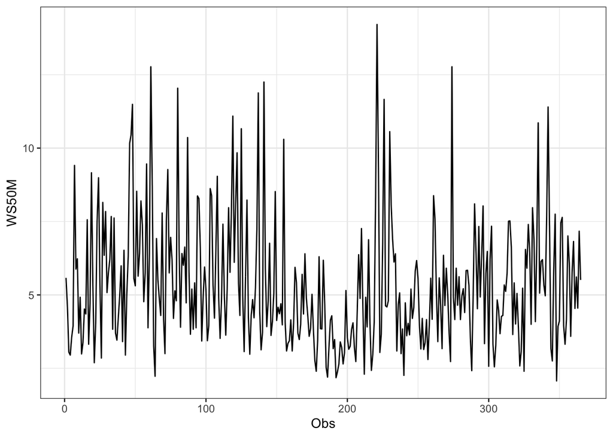

```r
plot_stas <- data1.ts |> as_tsibble() |>
  ggplot(aes(x = index, y = value)) + geom_line() + theme_bw() +
  xlab("Obs") + ylab("WS50M")
plot_stas
```

```r
mean(data1.ts)
```

```
## [1] 5.337589
```

Berdasarkan plot time series tersebut, terlihat bahwa data stasioner dalam rataan, ditandai dengan tidak adanya trend ataupun musiman pada data, namun tidak stasioner dalam ragam, ditandai dengan adanya perbedaan lebar pita pada plot

### Plot ACF

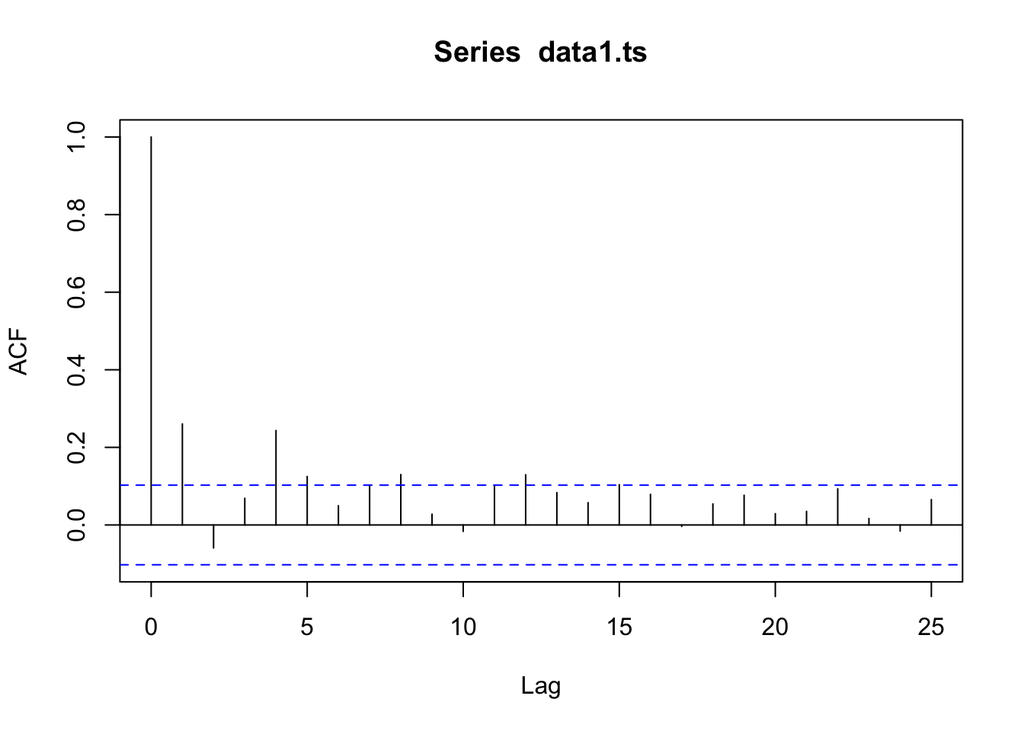

```r
acf(data1.ts)
```

Berdasarkan plot ACF, terlihat bahwa plot ACF pada data tersebut cenderung *tails off* dan membentuk gelombang sinus.

### Uji ADF

```r
adf.test(data1.ts)
```

```
##
##  Augmented Dickey-Fuller Test
##
## data:  data1.ts
## Dickey-Fuller = -4.7398, Lag order = 7, p-value = 0.01
## alternative hypothesis: stationary
```

$H_0$ : Data tidak stasioner dalam rataan

$H_1$ : Data stasioner dalam rataan

Berdasarkan uji ADF tersebut, didapat *p-value* sebesar 0.01 yang lebih kecil dari taraf nyata 5% sehingga tolak $H_0$ dan menandakan bahwa data stasioner dalam rataan. Hal ini sesuai dengan hasil eksplorasi menggunakan plot time series dan plot ACF.

### Plot Box-Cox

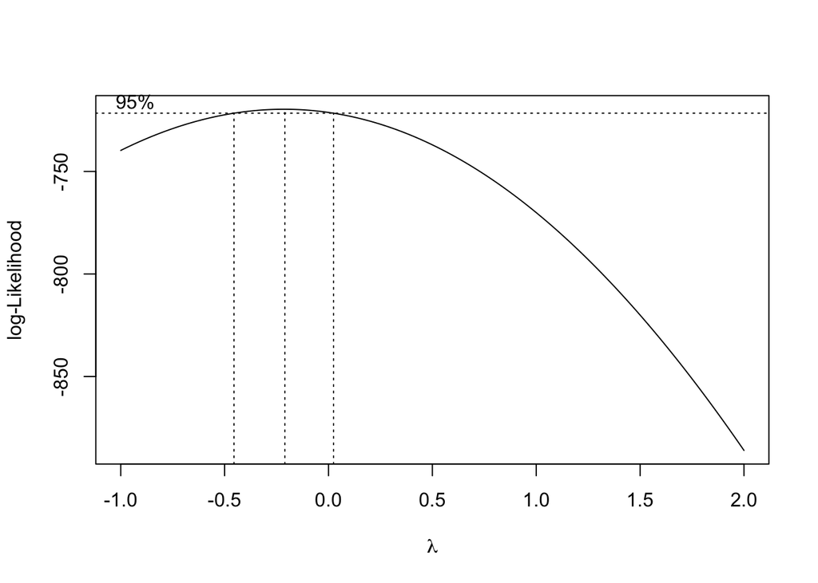

```r
index <- seq(1:365)
bc = boxcox(data1.ts~index, lambda = seq(-1,2,by=0.01))
```

```r
#Nilai Rounded Lambda
lambda <- bc$x[which.max(bc$y)]
lambda
```

```
## [1] -0.21
```

```r
#SK
bc$x[bc$y > max(bc$y) - 1/2 * qchisq(.95,1)]
```

```
##  [1] -0.45 -0.44 -0.43 -0.42 -0.41 -0.40 -0.39 -0.38 -0.37 -0.36 -0.35 -0.34
## [13] -0.33 -0.32 -0.31 -0.30 -0.29 -0.28 -0.27 -0.26 -0.25 -0.24 -0.23 -0.22
## [25] -0.21 -0.20 -0.19 -0.18 -0.17 -0.16 -0.15 -0.14 -0.13 -0.12 -0.11 -0.10
## [37] -0.09 -0.08 -0.07 -0.06 -0.05 -0.04 -0.03 -0.02 -0.01  0.00  0.01  0.02
```

Gambar di atas menunjukkan nilai *rounded value* ($\lambda$) optimum sebesar **-0.21** dan pada selang kepercayaan 95% nilai memiliki batas bawah **-0.45** dan batas atas **0.02**. Selang tersebut tidak memuat nilai satu sehingga dapat dikatakan bahwa data time series tidak stasioner dalam ragam.

### Partisi Data

#### Bagian 1

```r
dt_stas1 <- data1.ts[1:121] |> ts()
mean(dt_stas1)
```

```
## [1] 5.920909
```

```r
var(dt_stas1)
```

```
## [1] 4.86958
```

#### Plot Time Series

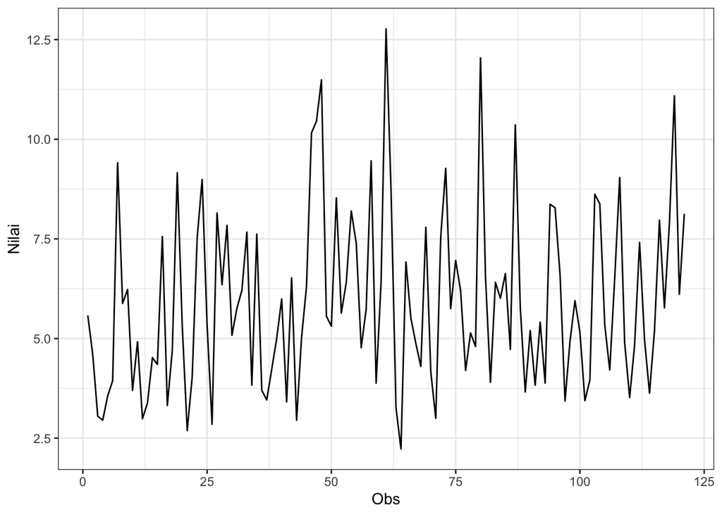

```r
dt_stas1 |> as_tsibble() |>
  ggplot(aes(x = index, y = value)) +
  geom_line() + theme_bw() +
  xlab("Obs") + ylab("Nilai")
```

#### Plot ACF

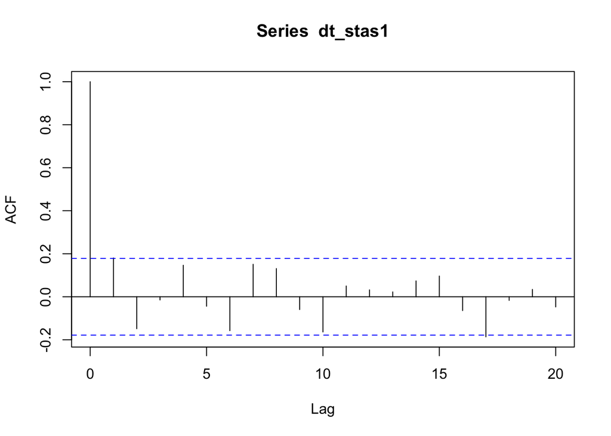

```r
acf(dt_stas1)
```

Berdasarkan plot ACF, terlihat bahwa plot ACF pada data tersebut cenderung *tails off* dan membentuk gelombang sinus.

#### Uji ADF

```r
adf.test(dt_stas1)
```

```
##
##  Augmented Dickey-Fuller Test
##
## data:  dt_stas1
## Dickey-Fuller = -4.9163, Lag order = 4, p-value = 0.01
## alternative hypothesis: stationary
```

$H_0$ : Data tidak stasioner dalam rataan

$H_1$ : Data stasioner dalam rataan

Berdasarkan uji ADF tersebut, didapat *p-value* sebesar 0.01 yang lebih kecil dari taraf nyata 5% sehingga tolak $H_0$ dan menandakan bahwa data stasioner dalam rataan. Hal ini sesuai dengan hasil eksplorasi menggunakan plot time series dan plot ACF.

#### Plot Boxcox

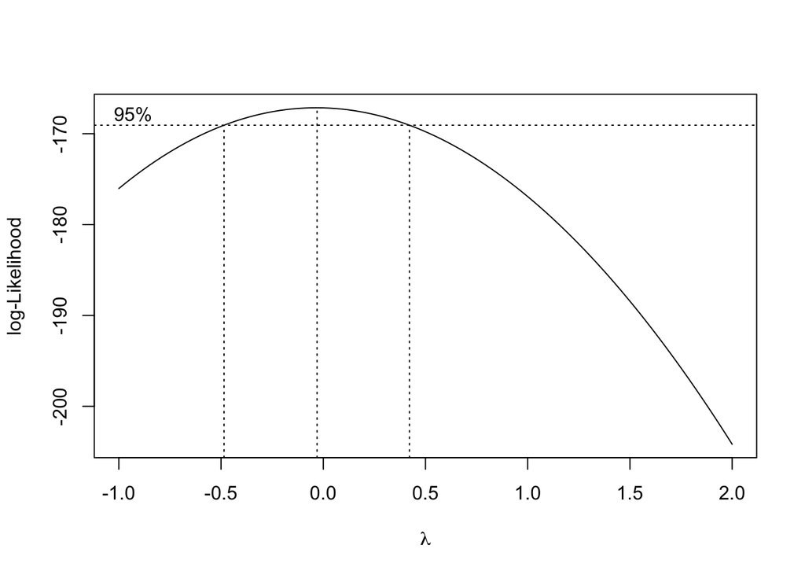

```r
index <- seq(1:121)
bc = boxcox(dt_stas1~index, lambda = seq(-1,2,by=1))
```

```r
#Nilai Rounded Lambda
lambda <- bc$x[which.max(bc$y)]
lambda
```

```
## [1] -0.03030303
```

```r
#SK
bc$x[bc$y > max(bc$y) - 1/2 * qchisq(.95,1)]
```

```
##  [1] -0.48484848 -0.45454545 -0.42424242 -0.39393939 -0.36363636 -0.33333333
##  [7] -0.30303030 -0.27272727 -0.24242424 -0.21212121 -0.18181818 -0.15151515
## [13] -0.12121212 -0.09090909 -0.06060606 -0.03030303  0.00000000  0.03030303
## [19]  0.06060606  0.09090909  0.12121212  0.15151515  0.18181818  0.21212121
## [25]  0.24242424  0.27272727  0.30303030  0.33333333  0.36363636  0.39393939
```

Gambar di atas menunjukkan nilai *rounded value* ($\lambda$) optimum sebesar **-0.03** dan pada selang kepercayaan 95% nilai memiliki batas bawah **-0.48** dan batas atas **0.39**. Selang tersebut tidak memuat nilai satu sehingga dapat dikatakan bahwa data time series tidak stasioner dalam ragam.

#### Bagian 2

```r
dt_stas2 <- data1.ts[1:242] |> ts()
mean(dt_stas2)
```

```
## [1] 5.390826
```

```r
var(dt_stas2)
```

```
## [1] 5.316906
```

#### Plot Time Series

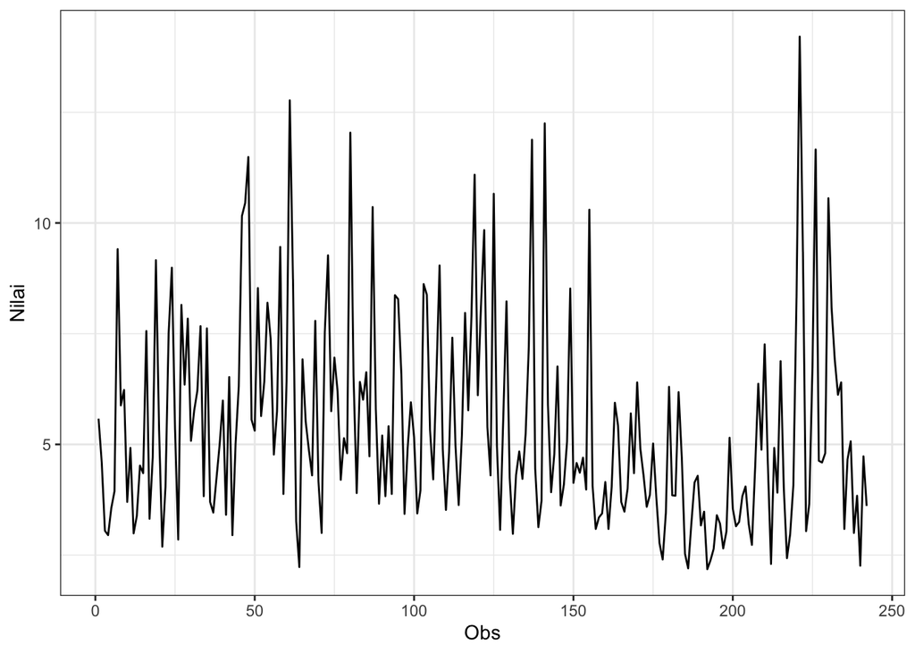

```r
dt_stas2 |> as_tsibble() |>
  ggplot(aes(x = index, y = value)) +
  geom_line() + theme_bw() +
  xlab("Obs") + ylab("Nilai")
```

Plot deret waktu di atas menunjukkan bahwa data stasioner dalam rataan, ditandai dengan data yang menyebar di sekitar nilai tengahnya (5) dan tidak stasioner dalam ragam, ditandai dengan lebar pita yang cenderung tidak sama.

#### Plot ACF

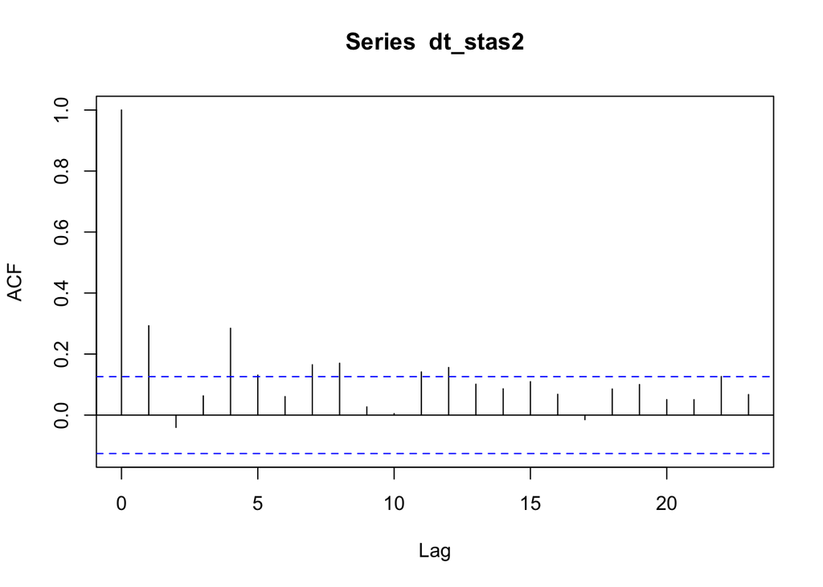

```r
acf(dt_stas2)
```

Berdasarkan plot ACF, terlihat bahwa plot ACF pada data tersebut cenderung *tails off* dan membentuk gelombang sinus.

#### Uji ADF

```r
adf.test(dt_stas2)
```

```
##
##  Augmented Dickey-Fuller Test
##
## data:  dt_stas2
## Dickey-Fuller = -3.896, Lag order = 6, p-value = 0.01484
## alternative hypothesis: stationary
```

$H_0$ : Data tidak stasioner dalam rataan

$H_1$ : Data stasioner dalam rataan

#### Plot Boxcox

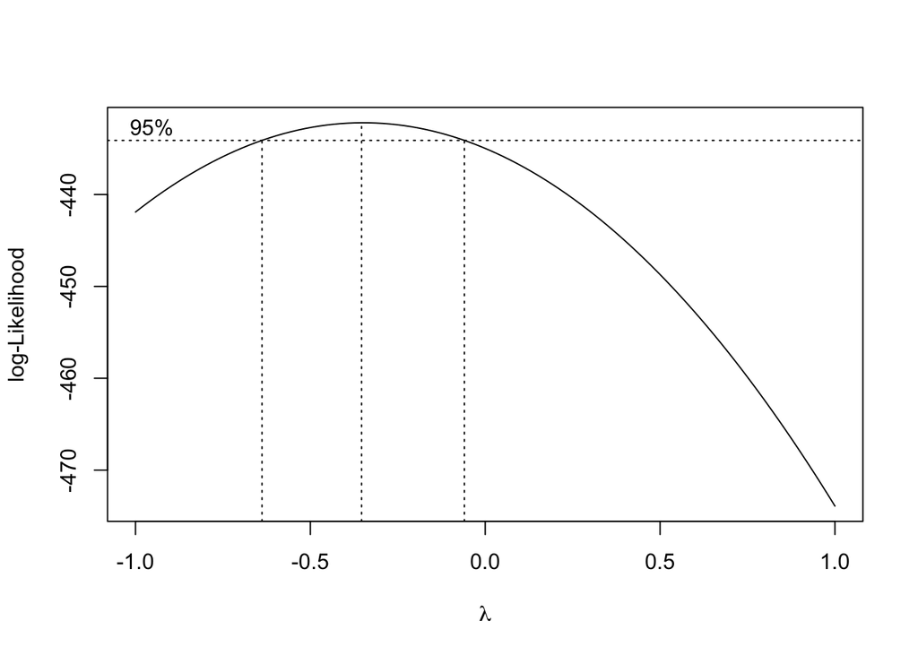

```r
index <- seq(1:242)
bc = boxcox(dt_stas2~index, lambda = seq(-1,1,by=1))
```

```r
#Nilai Rounded Lambda
lambda <- bc$x[which.max(bc$y)]
lambda
```

```
## [1] -0.3535354
```

```r
#SK
bc$x[bc$y > max(bc$y) - 1/2 * qchisq(.95,1)]
```

```
##  [1] -0.63636364 -0.61616162 -0.59595960 -0.57575758 -0.55555556 -0.53535354
##  [7] -0.51515152 -0.49494949 -0.47474747 -0.45454545 -0.43434343 -0.41414141
## [13] -0.39393939 -0.37373737 -0.35353535 -0.33333333 -0.31313131 -0.29292929
## [19] -0.27272727 -0.25252525 -0.23232323 -0.21212121 -0.19191919 -0.17171717
## [25] -0.15151515 -0.13131313 -0.11111111 -0.09090909 -0.07070707
```

Gambar di atas menunjukkan nilai *rounded value* ($\lambda$) optimum sebesar **-0.35** dan pada selang kepercayaan 95% nilai memiliki batas bawah **-0.63** dan batas atas **-0.07**. Selang tersebut tidak memuat nilai satu sehingga dapat dikatakan bahwa data time series tidak stasioner dalam ragam.